# BigBacter v2: Live Demo

Investigating a suspected *Corynebacterium striatum* outbreak

Jared Johnson, PhD

Washington State Department of Health

2026-11-25

# Setting the stage

## Scenario: A suspected outbreak

Epis reach out about a suspected *Corynebacterium striatum* outbreak and ask the lab to use whole genome sequencing to investigate.

[figure not shown]

**About *C. striatum***

Skin and mucosal commensal, increasingly recognized as a multidrug-resistant, healthcare-associated pathogen.

## Currently using BigBacter v1.0

[figure not shown]

The lab already uses BigBacter v1.0 … but *C. striatum* has never been analyzed before.

**We will need to find a PopPUNK database for this species! ([available databases](https://bacpop.org/poppunk-databases/))**

[figure not shown]

## Upgrading to BigBacter v2

[figure not shown]

BigBacter v2 replaces PopPUNK with a new tool called, floc.

**Floc builds each database automatically - no pre-configuration required!**

[figure not shown]

# Run 1

## 1. Getting started with BigBacter

[figure not shown]

## 2. Create the samplesheet

### Example:

```
samplesheets/samplesheet.1.csv
```

```
sample,taxa,assembly,fastq_1,fastq_2
sim01,Corynebacterium striatum,sim01.fasta.gz,sim01_R1.fastq.gz,sim01_R2.fastq.gz
sim02,Corynebacterium striatum,sim02.fasta.gz,sim02_R1.fastq.gz,sim02_R2.fastq.gz
```

### Description of fields:

- `taxa` and `assembly`: **reuse outputs from your routine pipeline**
- Skips taxonomic classification and assembly

## 3. Create the parameter file

### Example

```
params/params.1.yml
```

```yaml
input: samplesheets/samplesheet.1.csv
outdir: results
db: bigbacter_db/
push: false
```

### Description of fields

- `input`: path to samplesheet
- `outdir`: results for this run
- `db`: path to BigBacter database
- `push: false`: this will be updated later!

Parameter or config files are highly recommended for newer version of Nextflow!

## 4. Run BigBacter

### Example

```bash
nextflow run nw-page/bigbacter \
    -r main \
    -profile docker,pc \
    -params-file params/params.1.yml
```

### Description of fields

- `-r main`: use main branch of `nw-page/bigbacter` repo
- `-profile docker,pc`: use the Docker engine and adjust resources for running on a PC
- `-params-file`: use the params file we created on the previous slide

⏱ Should take about 3 mins to complete

# While that’s running…

## How BigBacter works

[figure not shown]

## Clustering with floc

[figure not shown]

Floc was designed as a **more flexible alternative to PopPUNK**.

[figure not shown]

- Databases are created **automatically** using a few as a **single sample**.
- Samples can be both added **and removed**.

# Run 1 results

## 5. Check the results

1. **Find the run.** Each run gets a run ID (a timestamp) and its own folder

   ```bash
   ls results/
   ```

2. **Open the run summary.** Which cluster did each sample land in, and how is it linked?

   ```bash
   results/<run ID>/<run ID>-summary.csv
   ```

3. **Open the Microreact report.** Drag it onto microreact.org/upload

   ```bash
   results/<run ID>/Corynebacterium_striatum/1/report/*.microreact
   ```

4. **Decide.** Happy with the results? Push them to the database

## 6. Push the samples

We are happy with these results, which means we are ready to push them to our database.

**We can do this by resuming the previous BigBacter run with `push` set to `true`.**

### Example

```
params/params.1.yml
```

```yaml
input: samplesheets/samplesheet.1.csv
outdir: results
db: bigbacter_db/
push: true
```

```bash
nextflow run nw-page/bigbacter -r main \
  -profile docker,pc \
  -params-file params/params.1.yml \
  -resume
```

### Description of fields

- `-resume`: reuses the cached work, so **nothing is recomputed**.
- `push: true`: push new files to the BigBacter database

⏱ Should take < 30 seconds

## The database grows with every run

[figure not shown]

# Run 2: adding contextual samples

## NCBI Pathogen Detection

We decide to submit one of the samples to NCBI and request it be added to the [Pathogen Detection site](https://www.ncbi.nlm.nih.gov/pathogens/).

This reveals two closely related genomes from a different lab!

**We want to add these samples to our BigBacter database…**

## Epi request

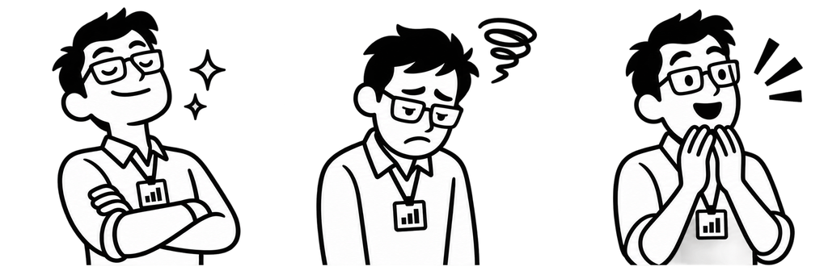

One of the genomic epis, **Dan**, is certain he has found an additional linkage on NCBI and has requested you include it…

…sure thing, Dan! 🙄

## Create the samplesheet (again)

### Example

```
samplesheets/samplesheet.2.csv
```

[output not shown]

### Description of fields

- `sample / taxa`: the same as before
- `genbank`: GenBank accession

BigBacter automatically downloads assemblies and reads from NCBI when supplied GenBank or SRA accessions!

## Run 2

Kick of the new run using the new samplesheet and params file!

### Example

```bash
nextflow run nw-page/bigbacter -r main \
  -profile docker,pc \
  -params-file params/params.2.yml
```

⏱ Should take about 2 mins to complete

# While that’s running…

## Core genome with polycore

[figure not shown]

## Reading the tree: linkage

[figure not shown]

## Run 2 results

| id | status | cluster | strong links | SNPs (min–max) |
| --- | --- | --- | --- | --- |
| GCA_002804085_1 | new | 1 | GCA_016085355_1, sim01, sim02, Reference_sim02 | 1–10 |
| GCA_016085355_1 | new | 1 | GCA_002804085_1 | 10–20 |
| sim01 | old | 1 | GCA_002804085_1 | 10–20 |
| sim02 | old | 1 | GCA_002804085_1, Reference_sim02 | 1–11 |
| **Dan_Request** | new | **2** | – | – |

- **GCA_002804085_1** is **1 SNP** from sim02: a public genome closely linked to our outbreak
- **Dan_Request** forms its own **cluster 2**, with its own reference → **not related**

## Push run 2 💻

Set `push: true` in `params/params.2.yml`, then:

```bash
nextflow run nw-page/bigbacter -r main \
  -profile docker,pc \
  -params-file params/params.2.yml \
  -resume
```

# Run 3: a new isolate

## One more isolate arrives

Weeks pass. The lab is deep in a **measles outbreak** when one more *C. striatum* isolate arrives.

```
samplesheets/samplesheet.3.csv
```

```
sample,taxa,assembly,fastq_1,fastq_2
sim03,Corynebacterium striatum,simulated/genomes/sim03.fasta.gz,simulated/fastq/sim03_R1.fastq.gz,simulated/fastq/sim03_R2.fastq.gz
```

- A **single sample** is fine. It’s compared against everything in the database

```bash
nextflow run nw-page/bigbacter -r main \
  -profile docker,pc \
  -params-file params/params.3.yml
```

## Run 3 results

| id | status | cluster | SNPs (min–max) |
| --- | --- | --- | --- |
| **sim03** | **new** | 1 | **0–10** |
| GCA_002804085_1 | old | 1 | 0–10 |
| GCA_016085355_1 | old | 1 | 10–20 |
| sim01 | old | 1 | 10–20 |
| sim02 | old | 1 | 1–11 |

## Push and share 💻

Set `push: true` in `params/params.3.yml`, then:

```bash
nextflow run nw-page/bigbacter -r main \
  -profile docker,pc \
  -params-file params/params.3.yml \
  -resume
```

Share the Microreact report and run summary with the epis.

# Wrap-up

## Takeaways

- **No PopPUNK database needed**: BigBacter v2 builds one for any species, from as few as **1 sample**
- **Run → review → push** with `-resume`, so only results you’ve checked go into the database
- The database **grows with every run**: new samples are compared against everything before them, and old samples aren’t reprocessed
- **Public context is just an accession** in the samplesheet
- Separate clusters are an answer too: **Dan_Request is not part of this outbreak**

## Resources

- Docs: [nw-page.github.io/bigbacter-docs](https://nw-page.github.io/bigbacter-docs/)
- Code: github.com/nw-page/bigbacter
- floc: github.com/nw-page/floc
- Demo files: [github.com/waphl-bioinformatics/presentations](https://github.com/waphl-bioinformatics/presentations/tree/main/bigbacter-demo)